# Assignment 5: Part 1

*How to do it?*:

- Open the Rmarkdown file of this assignment (link) in Rstudio.
- Right under each **question**, insert a code chunk (you can use the hotkey `Ctrl + Alt + I` to add a code chunk) and code the solution for the question.
- `Knit` the rmarkdown file (hotkey: `Ctrl + Alt + K`) to export an html.
- Publish the html file to your Githiub Page.

*Submission*: Submit the link on Github of the assignment to Canvas.

**Questions**

1. Use `read_csv` to import the data. Show the number of NAs for each columns.

```r
library(readr)
census <- read_csv("adult_census_missing.csv")
colSums(is.na(census))
```

```
##            age      workclass         fnlwgt      education  education.num
##             30             34              0             15              0
## marital.status     occupation   relationship           race            sex
##             26             35              0              0             24
##   capital.gain   capital.loss hours.per.week native.country         income
##              8              0              0             15              0
```

2. Using function `aggr` the VIM package to plot the number of NAs for each column.

```r
library(tidyverse)
library(VIM)
aggr(
  census,
  numbers = TRUE,
  prop = FALSE,
  cex.axis = 0.7,
  gap = 2
)
```

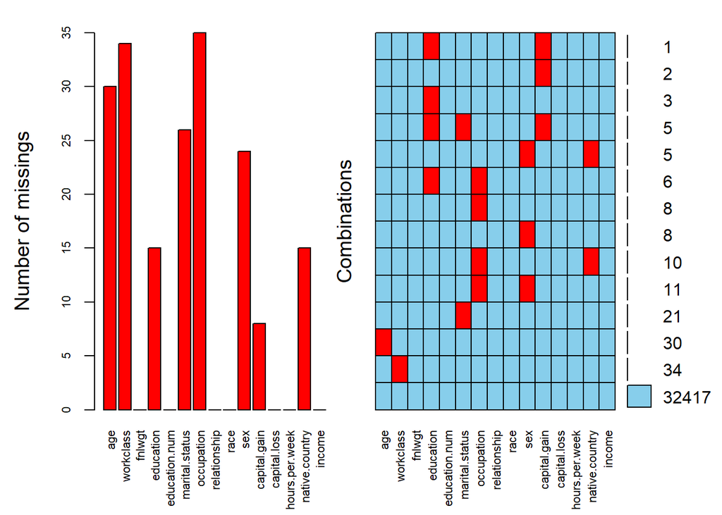

3. Find other forms of missing values. Hint: You can use the `table` function to check if there are suspicious categories (Unknown, for example) in a variable. What all other forms of missing values shown in the data.

```r
sapply(census, function(x) sum(x == "?", na.rm = TRUE))
```

```
##            age      workclass         fnlwgt      education  education.num
##              0           1835              0              0              0
## marital.status     occupation   relationship           race            sex
##              0           1840              0              0              0
##   capital.gain   capital.loss hours.per.week native.country         income
##              0              0              0            582              0
```

```r
sapply(census, function(x) sum(x == "", na.rm = TRUE))
```

```
##            age      workclass         fnlwgt      education  education.num
##              0              0              0              0              0
## marital.status     occupation   relationship           race            sex
##              0              0              0              0              0
##   capital.gain   capital.loss hours.per.week native.country         income
##              0              0              0              0              0
```

```r
sapply(census, function(x) sum(trimws(x) == "", na.rm = TRUE))
```

```
##            age      workclass         fnlwgt      education  education.num
##              0              0              0              0              0
## marital.status     occupation   relationship           race            sex
##              0              0              0              0              0
##   capital.gain   capital.loss hours.per.week native.country         income
##              0              0              0              0              0
```

4. Replace all the forms of missing values found to NA

```r
census[census == "?"] <- NA
census[census == ""] <- NA
census[trimws(census) == ""] <- NA
```

5. Replot the number of NAs for each column.

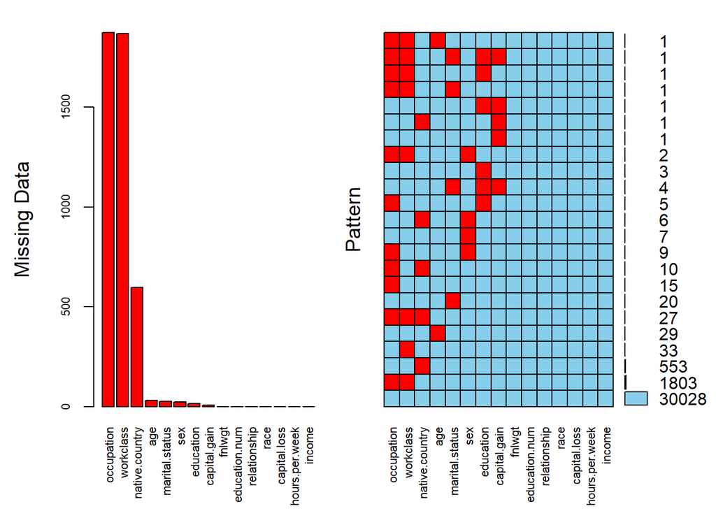

```
##
##  Variables sorted by number of missings:
##        Variable Count
##      occupation  1875
##       workclass  1869
##  native.country   597
##             age    30
##  marital.status    26
##             sex    24
##       education    15
##    capital.gain     8
##          fnlwgt     0
##   education.num     0
##    relationship     0
##            race     0
##    capital.loss     0
##  hours.per.week     0
##          income     0
```

```r
library(VIM)
aggr(census,
     numbers = TRUE,
     prop = FALSE,
     sortVars = TRUE,
     cex.axis = 0.7,
     gap = 3,
     ylab = c("Missing Data", "Pattern"))
```

6. Approach 1 to handle NAs: remove all rows that have any NAs. Save the dataset after removing as a different data. The original data is unchanged (still have NAs). How many rows left after removing?

```r
census_noNA <- na.omit(census)
nrow(census_noNA)
```

```
## [1] 30028
```

7. Approach 2 to handle NAs: Fill all the NAs with the previous or next value. (Hint: Using `fill` function). Save the dataset after filling as a different data. The original data is unchanged (still have NAs).

```r
library(tidyr)
census_fill <- census %>%
  fill(everything(), .direction = "down") %>%
  fill(everything(), .direction = "up")
colSums(is.na(census_fill))
```

```
##            age      workclass         fnlwgt      education  education.num
##              0              0              0              0              0
## marital.status     occupation   relationship           race            sex
##              0              0              0              0              0
##   capital.gain   capital.loss hours.per.week native.country         income
##              0              0              0              0              0
```

8. Approach 3 to handle NAs: For numeric variable, replace the NAs by the median. For categorical variables, replace the NAs to the majority.

```r
library(dplyr)

census_medmode <- census %>%
  mutate(across(
    .cols = everything(),
    .fns = ~ if (is.numeric(.x)) {
      replace(.x, is.na(.x), median(.x, na.rm = TRUE))
    } else {
      majority <- names(sort(table(.x), decreasing = TRUE))[1]
      replace(.x, is.na(.x), majority)
    }
  ))
```